# Loan Characterics on Borrower's APR using Propser Loan Data

## Dataset Overview

> The Dataset contains 113,917 loans, each row has infomation on the borrow's APR, status, borrowed amount, debt, etc. Variables with many missing values were dropped to make the Dataset more accurate.

> On November 24, 2008, the SEC found Prosper to be in violation of the Securities Act of 1933. As a result of these findings, the SEC imposed a cease and desist order on Prosper ... In July 2009, Prosper reopened their website for lending ("investing") and borrowing after having obtained SEC registration for its loans ("notes"). After the relaunch, bidding on loans was restricted to residents of 28 U.S. states and the District of Columbia. Borrowers may reside in any of 47 states, with residents of three states (Iowa, Maine, and North Dakota) not permitted to borrow through Prosper".

## Borrower APR

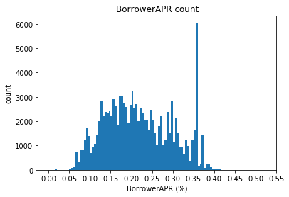

```python
bins = np.arange(0, df['BorrowerAPR'].max(), 0.005)
plt.hist(data = df, x = 'BorrowerAPR', bins = bins)
plt.title('BorrowerAPR count')
plt.xlabel('BorrowerAPR (%)')
plt.ylabel('count')
plt.xticks(np.arange(0, df['BorrowerAPR'].max()+0.05, 0.05));
```

The lowerest APR is at around 0.05% and the highested is at around 0.41%. Two high counts are found at 0.35797% and 0.35643%.

## BorrowerAPR vs. ProsperScore

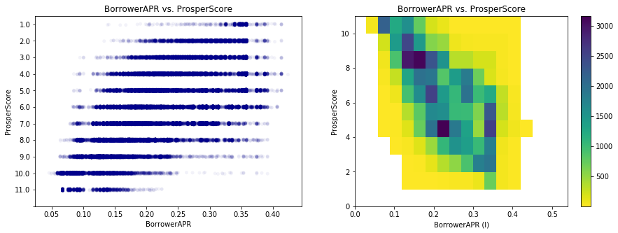

```python
#plotting BorrwerAPR vs ProsperScore
plt.figure(figsize = [15, 5])

plt.subplot(1, 2, 1)
sb.stripplot(data = df, x = 'BorrowerAPR', y = 'ProsperScore', jitter = 0.05, alpha = 0.05, orient='h',color='darkblue')
plt.yticks(np.arange(0, 12, 1))
plt.title('BorrowerAPR vs. ProsperScore')
plt.xlabel('BorrowerAPR')
plt.ylabel('ProsperScore')


plt.subplot(1, 2, 2)
bins_x = np.arange(0, df['BorrowerAPR'].max()+0.05, 0.03)
bins_y = np.arange(0, df['ProsperScore'].max()+1, 1)
plt.hist2d(data = df, x = 'BorrowerAPR', y = 'ProsperScore', bins = [bins_x, bins_y],
               cmap = 'viridis_r', cmin = 0.5)
plt.colorbar()
plt.title('BorrowerAPR vs. ProsperScore')
plt.xlabel('BorrowerAPR (l)')
plt.ylabel('ProsperScore');
```

The plot shows the negative correlation between BorrowerAPR and ProsperScore. The plot explain the higher the APR, the lower the ProsperScore is. This makes sense because borrowers with higher rating tend to received lower interest rate and APR.

# BorrowerAPR vs ProsperScore on each ProsperRatings

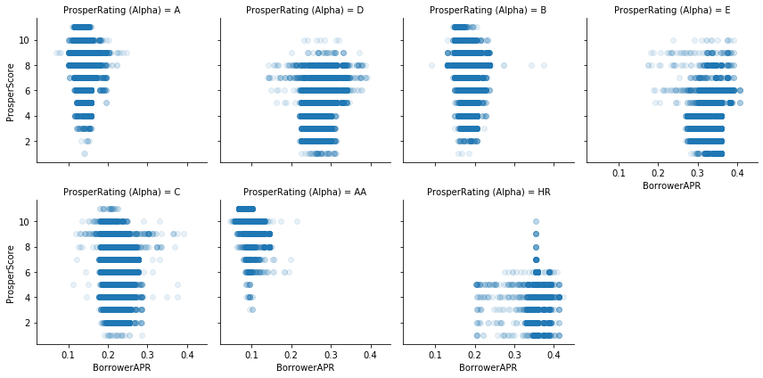

```python
g = sb.FacetGrid(data = df, col = 'ProsperRating (Alpha)', col_wrap = 4, size = 3)
g.map(plt.scatter, 'BorrowerAPR', 'ProsperScore', alpha = 0.1)
g.set_xlabels('BorrowerAPR')
g.set_ylabels('ProsperScore')

plt.show()
```

> The patterns shows the lowerest rating(HR) of borrowers have the highest APR percentage, and borrowers with high rating (AA) has the lowers APR percentage. This visualization differentiate groups of people in terms of APR received.

Thank You